# How Data Science Delivers Intent

## Bombora Data Science

[figure not shown]

- Nico Halecky, Ph.D., [@nehalecky](https://twitter.com/nehalecky)
- Data Science Director, [@bomboradata](https://twitter.com/bomboradata) (we're hiring)

# Of intent and content

## Intent Data?

> Data that is collected about business web users’ observed behavior - specifically web content consumption - that provides insights into their interests and from this indicate potential intent to take an action.

## Hypotheses

### (Bomborian interpretation of Intent)

- **H1**: User **intent** is *positively* correlated with user **interest**
- **H2**: User consumption of (web) content provides an *observable and quantifiable action* to measure interactions and engagement with topics.
- **H3**: Sampling such interactions *at scale* allows user interest to be inferred across many dimensions (e.g., time, geo, firmographic, demographic).

### Intent can be inferred by sampling user-content interactions at scale

# (Web) Content

[*Web Content*: Wikipedia](https://en.wikipedia.org/wiki/Web_content):

> is the textual, visual, or aural content that is encountered as part of the user experience on websites. It may include—among other things—text, images, sounds, videos, and animations.
- a web content concepts of interest can be understood through only *text* content.
- $\therefore$ **user** and **text-content** *interactions* are the **kernel** of interest

## How to quantify?

[figure not shown]

## Answer: Machine Learning!

[figure not shown]

## Reality: Start Somewhere

Conceptualize a user + content interaction event to be a user's *engagement* with *topics* event.

During interaction, capture:

1. Topics
2. Engagement

## DS Modeling Endeavor 1: Engagement

Not all interactions are the same. Capture that.

[figure not shown]

([Tony Haile—Chartbeat](http://time.com/12933/what-you-think-you-know-about-the-web-is-wrong/))

## Engagement model

> ranks a user's engagement with content (low, medium, high).

based on clustering model that considers normalized metrics:

- dwell time
- scroll depth
- scroll velocity
- device types

[figure not shown]

We refer to this task as *engagement weighting*, and is used as a feature in topic interest model.

## DS Modeling endeavor 2: Text to Topics

### text to topics

- consider *focused*, **topic-centric** view of the content-universe.
- transform text-content to an array of topic-concepts (and weights)

this task is known as *topic classification*

[figure not shown]

## Going Deep in NLP

### Why DL?

- State-of-the-art performance in supervised learning tasks
- No feature engineering

[figure not shown]

### In training comparisons, outperforms baseline model 20%*.

## Topic Classification Service (Tessie)

- Predicts topics from content, extracted from raw file.

### Model

- based on open source implementation of NLP on DL (from a big four company)
- custom corpus of topic-content data (topic taxonomy)
- leverages wiki corpus word embeddings
- model selection via Bayesian optimization

### Production System

- Runs on scalable processing nodes (Google App Engine)
- Cost 10% of previous service

## Topic Taxonomy

in Bombora lexicon:

> a classification framework that organizes verbal content into individually-addressable items, which are called *topics*. Content consumption across the Bombora co-op is captured, and topics are assigned to the content and weighted for relevancy.

## Topic Classification Examples

### Content: Bombora Surge Product

[figure not shown]

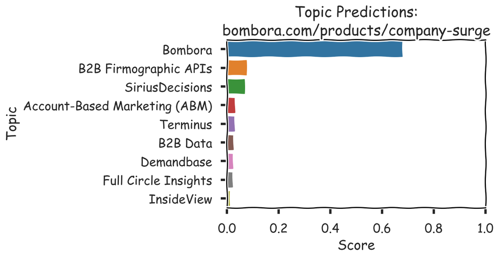

```
Company SurgeTM Discover Company SurgeTM Powered by the largest source of B2B Intent data, Company SurgeTM takes the guesswork out of sales and marketing. Marketers can find and drive active demand into the funnel while sales can prioritize accounts and win more business. Ride the Company SurgeTM wa…
```

```python
url = 'https://bombora.com/products/company-surge'
c = init_content(url)
inspect_content(c)
```

## Content: three perspectives

### Consider topic-concept: *Netflix*

> *Netflix* is an American entertainment company that specializes in and provides streaming media and video-on-demand online and DVD by mail.

### How does it vary across content?

### Concept: Creating TV Series from Video Game

[figure not shown]

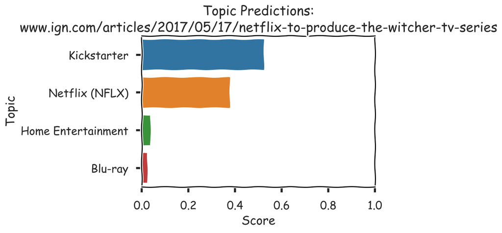

```
Netflix to Produce The Witcher TV Series Netflix will develop and produce a new show based on The Witcher Saga, the series of eight novels by Andrzej Sapkowski that inspired the hugely popular CD Projekt Red RPG games. Sapkowski - who does not profit from the game series - will serve as a creative c…
```

```python
url = 'http://www.ign.com/articles/2017/05/17/netflix-to-produce-the-witcher-tv-series'
c = init_content(url)
inspect_content(c)
```

### Concept: Fantasy *Casting* in Series

[figure not shown]

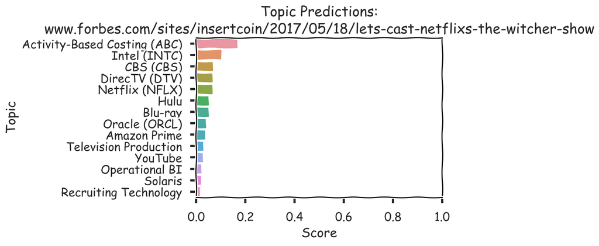

```
Let's Cast Netflix's Just-Announced 'The Witcher' TV Show News and opinion about video games, technology and the internetOpinions expressed by Forbes Contributors are their own. Photo: TAL COHEN/AFP/GettyImages Yesterday, news broke that Netflix was going to produce and air a TV series based on The …
```

```python
url = 'https://www.forbes.com/sites/insertcoin/2017/05/18/lets-cast-netflixs-the-witcher-show'
c = init_content(url)
inspect_content(c)
```

### Concept: Netflix Expenses

[figure not shown]

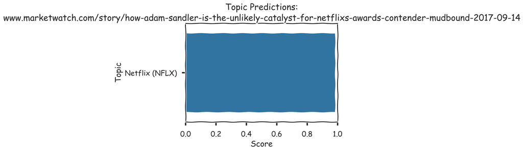

```
New York Markets After Hours How Adam Sandler convinced Netflix to spend $12.5 million on indie film ‘Mudbound’ After festival premieres, Dee Rees’s new film is a major awards contender Netflix/TIFF Carey Mulligan in a scene from Dee Rees's film 'Mudbound' By TomTeodorczuk Netflix, NFLX, -0.53% the …
```

```python
#url = 'http://www.latimes.com/business/hollywood/la-fi-ct-netflix-debt-spending-20170729-story.html'
#url = 'http://variety.com/2017/digital/news/netflix-20-million-per-hour-series-cfo-1202555399/'
url = 'http://www.marketwatch.com/story/how-adam-sandler-is-the-unlikely-catalyst-for-netflixs-awards-contender-mudbound-2017-09-14'
c = init_content(url)
inspect_content(c)
```

## Demonstrate topics are defined by:

- multiple labeled training document's content, combined with
- the model's *learning* of associating the label to human language represented in the documents

### *not* keywords, but rather, *labels* for **concepts**

## B2B Topic: Hyper-convergence Infrastruture

> *Hyper-Converged Infrastructure* is a system with a software-centric architecture that tightly integrates compute, storage, networking and virtualization resources and other technologies from scratch in a commodity hardware box supported by a single vendor.

[figure not shown]

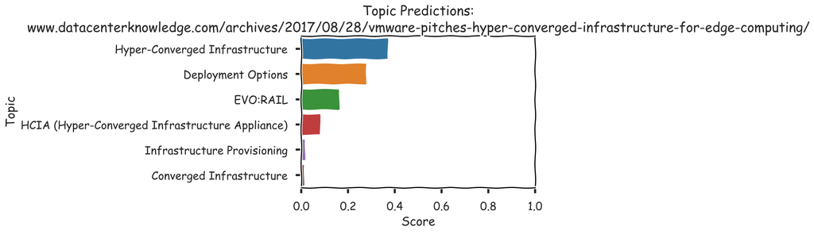

```
VMware Pitches Hyper-Converged Infrastructure for Edge Computing We don’t often get a chance to stick two buzz-phrases into one headline, but thanks to VMware, today is our lucky day. For companies looking to deploy edge computing, be it computers in retail stores, in remote offices, or on factory f…
```

```python
url = 'http://www.datacenterknowledge.com/archives/2017/08/28/vmware-pitches-hyper-converged-infrastructure-for-edge-computing/'
c = init_content(url)
inspect_content(c)
```

## Now what?

## Observe lots of interactions!

## HOW?

# Data co-op: observe, at scale

> the Bombora data co-op (DCO) is our B2B intent radio telescope network, finding interest-heavy topic-stars, scattered across domain galaxies in the internet cosmos.
- a tag-powered publisher acts as telescope, observing an (incredibly) small slice of content-interactions across the internet night sky
- collectively, contribute their content-interaction observations to a global pool
- continuous, real-time stream of observations

### Collects one billion observations/day (no more MongoDB)!

## Historical Daily Event Counts

[figure not shown]

## DS Modeling Endeavor 3: Topic Interest

Detect when interest in a topic is *significantly* (positive) from a particular domain

- Observe domain behaviors (normalized features) over time to establish profile / baseline
- compare current behavior with past baseline

We refer to this task as *anomaly detection*.

## Topic Interest Score Model (Surge)

> computes topic interest scores (a measure of topic interest across space, time, and company)
- leverages aggregated statistics of Bombora event datasets, yielding daily observations across different dimensions.
- combined and normalized to produce a desired feature setfor the model:
  - event counts
  - user counts
  - topic score weightings
  - engagement weightings)
- considers daily activity of the feature set of a 3-week *current* interval (i.e., 21 observations across all features), and compares it against a distribution of daily activity from a 12-week baseline (i.e., 84 observations).

## Example TI (Surge) Distribution

[figure not shown]

# DOES THIS WORK?

## DS analysis endeavor: Model Validation

### Closing the circle in interest inferring intent

Two methods:

- **Look Forward**: campaign case studies (aka bake offs)
- **Look Backward**: historical analyses

## Topic Interest Historical Analysis (TIHA)

> allows for understanding Bombora Topic Surge data product potential application across a variety of customer use cases. This is performed by providing a comparison of *surge* behavior domain and topic subset of interest, during an known historical sales cycle.

### Does surge data have predictive signals towards intent in my application?

## Example TIHA: Lenovo + HCI

- domain subset (200) and Opp Date (PoS time series)
- topic subset (100)
- experimental (real) and control (fake) records included

### Outputs

Summary stats comaparing target and control behavior

### Topic Group: HCI

- Hyper-Converged Infrastructure
- Converged Infrastructure
- Enterprise Infrastructure

## TIHA: Lenovo + HCI results

[figure not shown]

## TIHA: Lenovo + HCI results

[figure not shown]

## TIHA: Lenovo + HCI results

[figure not shown]

## Conclusion

### validation is forever, demonstrates there is signal

### Yes, meaningful intent *can* be inferred from interest derived from sampling user-content interactions, at scale!

### Data Science produces models providing meaning tranformations in our pipeline

### just starting to scratch the surface, up next:

- full graph representation of taxonomy / ontology
- multiple languages

# FIN

Thank you!

Questions?

[@nehalecky](https://twitter.com/nehalecky)

[@bomboradata](https://twitter.com/bomboradata) (we're hiring)

nhalecky@bombora.com